# Assignment 2

Irfan Kanat

March 8, 2018

This is an assignment to evaluate your learning in module two. For each learning activity there is a section in this document. Answer each question below the question and create an R Markdown document for submission.

*For the rest of the exercises we will use games.csv in the data folder. Import the file into a data.frame called games to begin the exercise.*

```r
# Import necessary packages
library(ggplot2)
# Import games.csv from data folder
games <- read.csv("data/games.csv")
```

## 1 - Describe

### Visual Inspection

Show the top 6 rows of *games*.

```r
head(games)
```

```
##   appID dateMonth    status     avgMin listPrice  reviews multi
## 1   280    201601 SuperStar   75.52385  9.986786 83.00000     0
## 2  1250    201601 SuperStar 2103.36076 19.986786 96.00000     1
## 3  2300    201601     Niche   33.73054  4.986786 90.00000     1
## 4  3340    201601     Niche  146.63755  4.986786 10.00000     0
## 5  3960    201601     Niche   98.04734  4.990000 36.78571     1
## 6  4770    201601   Popular  125.17656  4.986786 73.00000     1
```

### Descriptive Statistics

Use *summary* function to provide basic descriptive statistics for *games*.

```r
summary(games)
```

```
##      appID          dateMonth            status        avgMin
##  Min.   :   280   Min.   :201601   Niche    :323   Min.   :   0.00
##  1st Qu.:205796   1st Qu.:201601   Popular  : 26   1st Qu.:   0.00
##  Median :263040   Median :201601   SuperStar:  9   Median :  80.86
##  Mean   :231540   Mean   :201601                   Mean   : 274.98
##  3rd Qu.:315542   3rd Qu.:201601                   3rd Qu.: 223.34
##  Max.   :423880   Max.   :201601                   Max.   :9365.34
##
##    listPrice         reviews          multi
##  Min.   : 0.000   Min.   :10.00   Min.   :0.0000
##  1st Qu.: 4.987   1st Qu.:57.46   1st Qu.:0.0000
##  Median : 9.987   Median :75.57   Median :0.0000
##  Mean   :11.493   Mean   :68.77   Mean   :0.3212
##  3rd Qu.:14.987   3rd Qu.:89.00   3rd Qu.:1.0000
##  Max.   :89.990   Max.   :98.00   Max.   :1.0000
##  NA's   :11       NA's   :37
```

Use *str* function to provide an overview of data structure for *games*.

```r
str(games)
```

```
## 'data.frame':    358 obs. of  7 variables:
##  $ appID    : int  280 1250 2300 3340 3960 4770 4870 4890 6200 7670 ...
##  $ dateMonth: int  201601 201601 201601 201601 201601 201601 201601 201601 201601 201601 ...
##  $ status   : Factor w/ 3 levels "Niche","Popular",..: 3 3 1 1 1 2 1 1 1 3 ...
##  $ avgMin   : num  75.5 2103.4 33.7 146.6 98 ...
##  $ listPrice: num  9.99 19.99 4.99 4.99 4.99 ...
##  $ reviews  : num  83 96 90 10 36.8 ...
##  $ multi    : int  0 1 1 0 1 1 0 1 0 0 ...
```

## 2 - Visualization

### Histogram

Plot out the distribution of price variable in a histogram.

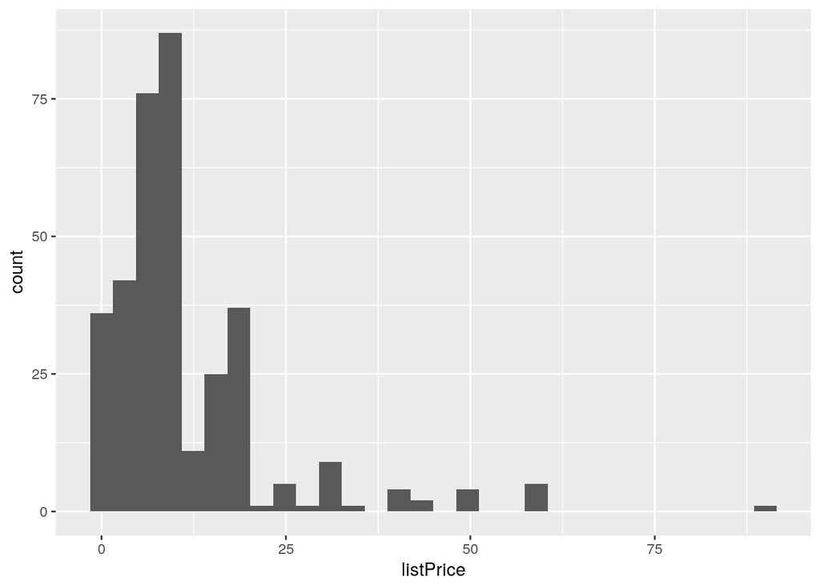

```r
qplot(x = listPrice, data = games, geom = "histogram")
```

### Scatter Plot

Plot the relation between avgMin (on average how much time players spent in game) and reviews.

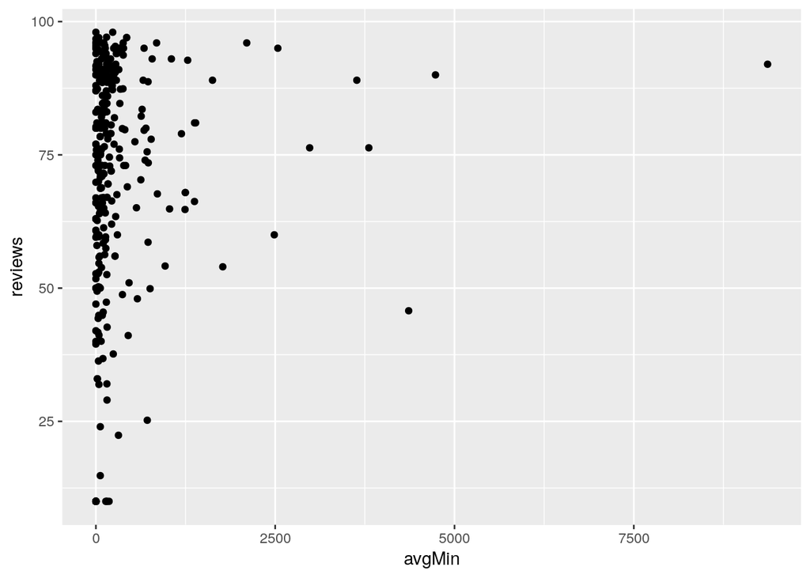

```r
qplot(x = avgMin, y = reviews, data = games)
```

### Bar Chart

Plot the frequency of status types in *games*.

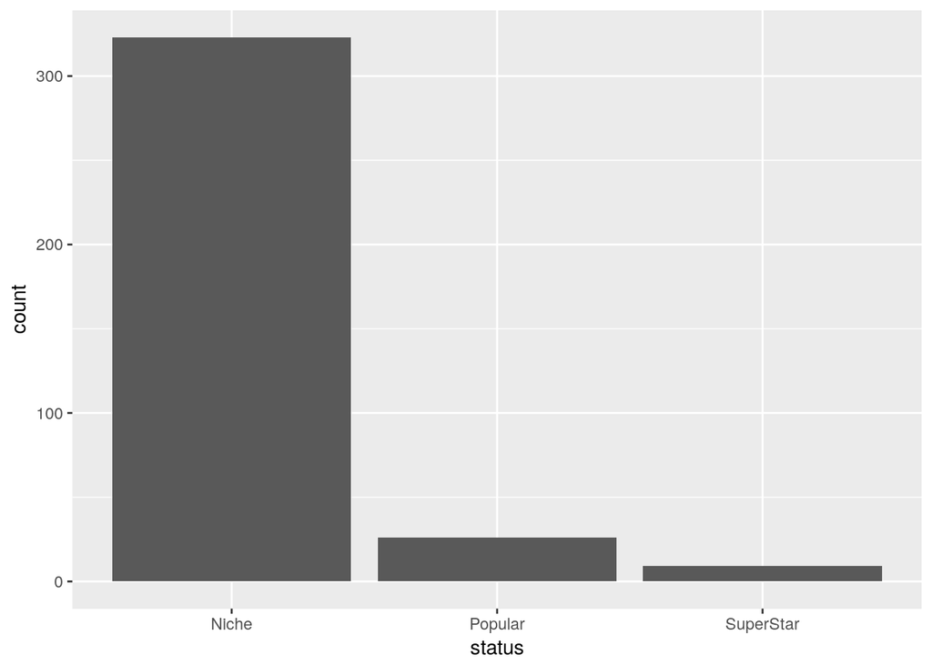

```r
qplot(x = status, data = games, geom = "bar")
```

## 3 - Subsetting

### Selecting Rows and Columns

Show only the games that have SuperStar status.

```r
games[games$status == "SuperStar",]
```

```
##      appID dateMonth    status     avgMin listPrice reviews multi
## 1      280    201601 SuperStar   75.52385  9.986786      83     0
## 2     1250    201601 SuperStar 2103.36076 19.986786      96     1
## 10    7670    201601 SuperStar  284.50698 19.977143      94     0
## 12    8190    201601 SuperStar  784.62215 14.986786      93     0
## 70   70000    201601 SuperStar  114.52498  9.965357      84     1
## 86  200510    201601 SuperStar 2536.72044 29.977143      95     1
## 130 226320    201601 SuperStar 1375.69520  0.000000      81     0
## 142 236850    201601 SuperStar 9365.33796 39.986786      92     1
## 319 363970    201601 SuperStar 4734.80276  0.000000      90     0
```

```r
games[,1:3]
```

```
##      appID dateMonth    status
## 1      280    201601 SuperStar
## 2     1250    201601 SuperStar
## 3     2300    201601     Niche
## 4     3340    201601     Niche
## 5     3960    201601     Niche
## 6     4770    201601   Popular
## 7     4870    201601     Niche
## 8     4890    201601     Niche
## 9     6200    201601     Niche
## 10    7670    201601 SuperStar
## 11    7970    201601     Niche
## 12    8190    201601 SuperStar
## 13    8310    201601     Niche
## 14    8660    201601   Popular
```

[output cut: 344 more lines]

### Aggregating

Calculate the average price for each status category, save the results into a data.frame called *gameAvgPrice*.

```r
# Using formula interface for aggregate
gameAvgPrice <- aggregate(listPrice ~ status, games, mean)
```

Change the name of the column listPrice in *gameAvgPrice* to avgCategoryPrice.

```r
colnames(gameAvgPrice) <- c("status", "avgCategoryPrice")
```

### Combine Datasets

Combine *games* and *gameAvgPrice* so that the average price for category is displayed next to each game. Save the results into *games* data.frame.

I want column avgCategoryPrice to be added to games, in such a way that it shows the average price for the correct status. A game that is a niche player will show 10.87 in avgCategoryPrice for example.

```r
games <- merge(games, gameAvgPrice, by="status")
```

## Transformations

Add a new column to *games* named logListPrice, and store log transformed list price in this column. Don’t forget log of 0 is meaningless, take the necessary precautions to ensure this does not lead to loss of data.

```r
games$logListPrice <- log(games$listPrice + 1)
```

## Missing Data

Show how many rows there are in games.

```r
nrow(games)
```

```
## [1] 358
```

Exclude any observations that are missing data on reviews column. Save the resulting data.frame in *games*

```r
games <- games[!is.na(games$reviews),]
```

Show how many rows there are after removal of observations.

```r
nrow(games)
```

```
## [1] 321
```

## Dimension Reduction

WIP